# Econometria Aplicada à Finanças Aula 8

Mestrado Profissional em Administração

Prof. Washington Santos da Silva

IFMG - Campus Formiga

7 de outubro de 2025

## Diário de Bordo

**O que vimos até o momento?**

- Aula 1 ✅
  - Apresentação da Disciplina ✅
  - Introdução ao RStudio ✅
  - Configurando o Projeto da Disciplina ✅
  - Conheça e Utilize o Terminal Git Bash ✅
- Aula 2 ✅
  - Git e GitHub: Visão Geral ✅
  - Introdução ao Sistema: Visão Geral ✅
  - Linguagem R: Visão Geral ✅
  - Sessão Prática 1 ✅
- Aula 3 ✅
  - Minicurso Intensivo: Teoria da Probabilidade - Parte 1 ✅
    - Introdução à Teoria da Probabilidade ✅
    - Variáveis Aleatórias e Distribuições de Probabilidade ✅
    - Distribuições Conjunta, Marginal e Condicional ✅
    - Independência de Variáveis Aleatórias ✅
- Aula 4 ✅
  - Minicurso Intensivo: Teoria da Probabilidade - Parte 2 ✅
    - Conceitos Básicos: Revisão ✅
    - Momentos de Distribuições de Probabilidade Univariadas ✅
    - Funções de Variáveis Aleatórias ✅
    - Fundamentos de Distribuições de Probabilidade Multivariadas ✅
    - Cálculo Diferencial e Integral em R
- Aula 5 ✅
  - Minicurso Intensivo: Teoria da Probabilidade - Parte 3 ✅
  - Distribuições de Variáveis Aleatórias Discretas ✅
  - Distribuições de Variáveis Aleatórias Contínuas ✅
  - Distribuições de Vetores Aleatórios ✅
  - A Ponte entre Probabilidade e Estatística/Econometria ✅
- Aula 6 ✅
  - Minicurso Intensivo: Métodos de Inferência Estatística I ✅
  - Estimação de Parâmetros: O Básico ✅
  - Métodos de Estimação de Parâmetros ✅
  - Estimação pode Intervalos de Confiança ✅
- Aula 7 ✅
  - Minicurso Intensivo: Métodos de Inferência Estatística II ✅
  - Propriedades dos Estimadores de Máxima Verossimilhança
  - Testes de Hipóteses (ou de Significância)

## Nesta Aula

**Tópicos**

- Modelo de Regressão Linear: Fundamento
- Modelo de Regressão Linear Simples
  - Diversos Aspectos

**Diretrizes para Aulas Mais Produtivas**

⌨️ **Código com método:**

95% dos erros são evitáveis com:

- Respeitar a sequência lógica de etapas
- Revisão antes de pedir ajuda
- Atenção na digitação

🤝 **Inteligência colaborativa:**

- Compartilhe conhecimento
- Resolva questões técnicas simples com colegas próximos
- Reserve ao professor as dúvidas conceituais complexas

💪 **Capacidade de Resolver Problemas**

Cada problema/erro resolvido é uma evolução da sua habilidade analítica

# Modelo Clássico de Regressão Linear: Fundamento

## Modelos de Regressão Linear

**Visão Geral**

- Os modelos de regressão linear são uma das ferramentas mais fundamentais da econometria aplicada.

#### Mas o que é a análise de regressão?

- A análise de regressão busca **descrever** e **quantificar** a relação entre uma variável (**dependente**) e uma ou mais variáveis explicativas (**independentes**).
- O objetivo é entender **como a média da variável dependente se comporta condicionalmente** aos valores das variáveis independentes — isto é, estudar a **função de expectativa condicional**.

## Modelos de Regressão Linear

**Por que nos preocupamos tanto com modelos de regressão linear?**

- Uma das razões é que os estimadores de mínimos quadrados ordinários de models de regressão linear são bons estimadores, se certas hipóteses forem verdadeiras.
- Em termos probabílisticos, o verdadeiro objetivo da regressão linear é entender como a média da variável dependente $Y$ se comporta para diferentes valores da variável explicativa $X$**.
- iIsso significa estimar a **Função de Expectativa Condicional (FEC)**: $E[Y \mid X]$
- O método dos Mínimos Quadrados Ordinários (OLS) é importante porque, entre todas as funções lineares, ele fornece a **melhor aproximação linear da FEC**.
- Portanto, entender a FEC é essencial para compreender o que a regressão linear realmente está estimando.

## Função de Expectativa Condicional (FEC)

**Descrição Geral**

A **função de expectativa condicional** (FEC) de uma variável dependente $Y_i$, dado um vetor de variáveis explicativas $X_i \in \mathbb{R}^K$, representa o valor esperado de $Y_i$ para cada possível valor fixado de $X_i$.

Escrevemos:
$$\mathop{E}[Y_i \mid X_i]$$

Que é uma **função** dos valores possíveis de $X_i$ — isto é, para cada valor de $X_i$, a FEC nos fornece a média populacional correspondente de $Y_i$.

Exemplos:

- $\mathop{E}\left[ \text{Renda}_i \mid \text{Educação}_i \right]$
- $\mathop{E}\left[ \text{Salário}_i \mid \text{Gênero}_i \right]$

## Função de Expectativa Condicional (FEC)

**Definição Formal**

Seja $Y_i$ uma variável aleatória contínua com densidade condicional $f_{Y \mid X}(t \mid X_i = x)$.

A função de expectativa condicional de $Y_i$ dado $X_i = x$ é definida como:

$$\mathop{E}[Y_i \mid X_i = x] = \int_{-\infty}^{\infty} t \cdot f_{Y \mid X}(t \mid x)\, dt$$

Ou seja, estamos calculando a média de $Y_i$ condicional à informação de que $X_i = x$, ponderando os valores possíveis de $Y_i$ pela sua densidade condicional.

**Importância:**

- A FEC é um **objeto populacional** — não depende de uma amostra, mas da distribuição verdadeira da população.
- Ela serve como ponto de partida para a formulação do modelo de regressão linear: queremos estimar ou aproximar essa função com base em dados.

## Função de Expectativa Condicional e Regressão Linear

**Propriedades**

#### Teorema 1 — Linearidade da FEC

Se a função de expectativa condicional é linear, isto é:

$$\mathop{E}[Y_i \mid X_i] = \beta_0 + \beta_1 X_i,$$

então essa própria função é a **função de regressão linear populacional**.  
Nesse caso, não há aproximação — estamos modelando a FEC exatamente.

#### Teorema 2 — Melhor preditor linear

A função de regressão linear populacional é o **melhor preditor linear** de $Y_i$ dado $X_i$, no sentido do **erro quadrático médio (EQM) mínimo** entre todas as funções lineares.

#### Teorema 3 — Melhor aproximação linear da FEC

Mesmo quando $\mathop{E}[Y_i \mid X_i]$ **não é linear**, a função de regressão linear populacional fornece a **melhor aproximação linear** da FEC (novamente, no sentido de erro quadrático médio):

$$\beta_0 + \beta_1 X_i = \mathop{argmin}_{a, b} \; \mathbb{E} \left[ \left( \mathop{E}[Y_i \mid X_i] - (a + b X_i) \right)^2 \right]$$

- O Teorema 3 justifica o uso da regressão linear **mesmo quando a relação entre $Y$ e $X$ não é linear**: isto é, a regressão linear é a **melhor reta possível** para resumir a média condicional.

## Distribuições Condicionais

[figure not shown]

Figura 1: Distribuições condicionais de $Y_i$ dado $X_i = x$, para $x = 8,...,22$. Cada curva representa a distribuição de $Y_i$ em um subgrupo da população com o mesmo nível de $X_i$ (anos de educação).

## Função de Expecativa Condicional

[figure not shown]

Figura 2: Estimativa empírica da função de expectativa condicional $E[Y_i | X_i]$. Os pontos brancos representam a média de $Y_i$ para cada valor de $X_i$; a linha branca conecta essas médias e ilustra a CEF.

## Função de Expecativa Condicional

[figure not shown]

Figura 3: A função de expectativa condicional $E[Y_i | X_i]$ como linha que conecta as médias condicionais. O fundo mostra as distribuições de $Y_i$ para cada valor de $X_i$, agora sem preenchimento para destacar a FEC.

## Função de Expecativa Condicional

**Por que a FEC?**

- A **função de expectativa condicional (FEC)** é o principal objeto de interesse na análise de regressão, porque ela resume a tendência central da variável dependente $Y$ dada a informação disponível sobre a variável explicativa $X$.
- Como já vimos, entender $E[Y \mid X]$ é mais eficiente do que entender a distribuição conjunta de $Y$ e $X$, pois $E[Y \mid X]$ descreve como a média da população, ou seja de $Y$, muda com $X$.

## Função de Expectativa Condicional e Regressão Linear Populacional

[figure not shown]

Figura 4: Comparação entre a função de expectativa condicional $E[Y_i | X_i]$ (linha cinza escura) e a função de regressão linear populacional (reta laranja). A regressão linear fornece a melhor aproximação linear da FEC.

## Modelo de Regressão Linear

**Fundamento Teórico**

A função de regressão linear populacional aproxima a função de expectativa condicional $E[Y_i \mid X_i]$ **da melhor forma possível entre todas as retas**, no sentido de minimizar o **erro quadrático médio**:

$$\beta_0 + \beta_1 X_i = \mathop{argmin}_{\beta_0, \beta_1} \; E\left[\left(E[Y_i \mid X_i] - (\beta_0 + \beta_1 X_i)\right)^2\right]$$

Essa é a **justificativa teórica** para o uso da regressão linear: mesmo quando a verdadeira relação entre $Y$ e $X$ não é linear, a regressão linear fornece a **melhor reta** para aproximá-la.

# Modelo de Regressão Linear Simples

## Modelo de Regressão Linear Simples

**Derivação do Modelo**

Suponha que desejamos estimar $E(Y \mid X)$ (FEC) para uma certa população.

Se a FEC for:

$$E(Y \mid X) = \beta_0 + \beta_1 X$$

e definimos

$$\varepsilon = Y - \beta_0 - \beta_1 X,$$

então, podemos escrever:

$$Y = \beta_0 + \beta_1 X + \varepsilon, \qquad E(\varepsilon \mid X) = 0$$

uma vez que:

$$E(\varepsilon \mid X)
= E(Y - \beta_0 - \beta_1 X \mid X)
= E(Y \mid X) - \beta_0 - \beta_1 X
= 0$$

Ou seja, a função de **regressão linear populacional** coincide com a função de **expectativa condicional** — quando a especificação linear é correta.

## Modelo de Regressão Linear Simples

**Derivação do Modelo**

Note que:

$$E(\varepsilon \mid X) = 0
\;\;\;\;\;\Longrightarrow\;\;\;\;\;
E(\varepsilon) = 0 \quad \text{e} \quad E(\varepsilon X) = 0$$

Além disso:

$$E(Y \mid X) = \beta_0 + \beta_1 X
\;\;\;\;\;\Longrightarrow\;\;\;\;\;
\beta_1 = \frac{\text{Cov}(X, Y)}{\text{Var}(X)}
\quad \text{e} \quad
\beta_0 = E(Y) - \beta_1 E(X)$$

Nosso objetivo é **estimar $\beta_0$ e $\beta_1$** a partir de uma amostra $\{(Y_i, X_i)\}_{i=1}^n$ retirada da população.

## Modelo de Regressão Linear Simples

**Derivação do Modelo**

Se a amostra é representativa da população, podemos escrever:

$$Y_i = \beta_0 + \beta_1 X_i + \varepsilon_i,
\qquad E(\varepsilon_i \mid X_i) = 0, \quad i = 1, \dots, n$$

Se a amostra é aleatória (i.i.d), podemos estender para:

$$Y_i = \beta_0 + \beta_1 X_i + \varepsilon_i,$$

com as condições:

$$E(\varepsilon_i \mid X_1, \dots, X_n) = 0$$

e

$$E(\varepsilon_i \varepsilon_j \mid X_1, \dots, X_n) = 0,
\quad \text{para } i \neq j, \;\; i, j = 1, \dots, n.$$

Este é o **modelo de regressão linear simples**.

## Exogeneidade Estrita

**Implicações**

Se $E(\varepsilon \mid X) = 0$, então:

$$E(\varepsilon) = 0 \quad \text{e} \quad \mathrm{Cov}(X, \varepsilon) = 0.$$

**Demonstração:**

#### (i) $E(\varepsilon) = 0$

Usamos a **Lei das Expectativas Iteradas**, que afirma que:

$$E(\varepsilon) = E\big( E(\varepsilon \mid X) \big)$$

Como a hipótese é que $E(\varepsilon \mid X) = 0$, temos:

$$E(\varepsilon) = E(0) = 0$$

#### (ii) $\mathrm{Cov}(X, \varepsilon) = 0$

Pela definição de covariância:

$$\mathrm{Cov}(X, \varepsilon) = E(X \varepsilon) - E(X)E(\varepsilon)$$

Do item (i), já sabemos que $E(\varepsilon) = 0$, então:

$$\mathrm{Cov}(X, \varepsilon) = E(X \varepsilon)$$

Agora usamos novamente que $E(\varepsilon \mid X) = 0$.

Como estamos condicionando em $X$, isso significa que o valor de $X$ já é conhecido naquele momento. Assim, ao calcular a expecativa de $X \varepsilon$, podemos reescrevê-la como:

$$E(X \varepsilon) = E\big( E(X \varepsilon \mid X) \big)$$

Como $X$ é conhecido dentro da condicional, podemos tratá-lo como constante e remover da expecativa condicional:

$$E(X \varepsilon \mid X) = X \cdot E(\varepsilon \mid X)$$

Portanto:

$$E(X \varepsilon) = E\big( X \cdot E(\varepsilon \mid X) \big)$$

E como $E(\varepsilon \mid X) = 0$, concluímos:

$$E(X \varepsilon) = E(X \cdot 0) = 0$$

## Modelo de Regressão Linear Simples

**Processo Gerador dos Dados**

Assumimos que os dados observados sobre a relação entre $y_i$ e $x_i$ são gerados por um processo linear com um componente aleatório:

$$y_i = \beta_0 + \beta_1 x_i + \varepsilon_i$$

- Os coeficientes $\beta_0$ e $\beta_1$ são parâmetros **populacionais desconhecidos**.
- O termo $\varepsilon_i$ representa um erro aleatório.

#### Por que incluímos o termo de erro $\varepsilon_i$?

O erro aleatório $\varepsilon_i$ cumpre o papel de capturar tudo que afeta $y_i$ e que não está incluído explicitamente no modelo:

- **Omissão de variáveis relevantes**: fatores que influenciam $y_i$ além de $x_i$.
- **Erros de medição** na variável dependente.
- **Choques aleatórios**

#### Modelo = Aproximação da Realidade

- Essa formulação nos permite pensar o modelo de regressão linear como uma aproximação do processo aleatório real que gerou os dados.
- Cabe ao pesquisador avaliar se essa aproximação é adequada para os objetivos do estudo e para as características dos dados observados.

## Nomes alternativos para $y$ e $x$:

| $y$ | $x$ |
| --- | --- |
| variável dependente | variável independente |
| variável explicada | variável explicativa |
| variável de efeito | variável causal |
| variável resposta | variáveis preditora/característica |
| regressando | regressor |

## Hipóteses do Modelo de Regressão Linear Simples

**Descrição**

**H1: Modelo Econométrico**

Todos os pares de dados $(y_i, x_i)$ coletados de uma população satisfazem a relação

$$y_i = \beta_1 + \beta_2 x_i + e_i,\quad i = 1, \dots, N$$

**H2: Exogeneidade Estrita**

O valor esperado condicional do erro aleatório $e_i$ é zero. Se $\mathbf{x} = (x_1, x_2, \dots, x_N)$, então

$$E(e_i \mid \mathbf{x}) = 0$$

**H3: Homocedasticidade Condicional**

A variância condicional do erro aleatório é constante:

$$V(e_i \mid \mathbf{x}) = \sigma^2$$

**H4: Erros Condicionalmente Não Correlacionados**

A covariância condicional dos erros aleatórios $e_i$ e $e_j$ é zero:

$$\mathrm{Cov}(e_i, e_j \mid \mathbf{x}) = 0,\quad i \neq j$$

**H5: Variabilidade da Variável Explicativa**

Em uma amostra de dados, $x_i$ deve assumir pelo menos dois valores diferentes.

**H6: Normalidade do Erro (opcional)**

A distribuição condicional dos erros aleatórios é normal:

$$e_i \mid \mathbf{x} \sim N(0, \sigma^2)$$

## Estimadores de Mínimos Quadrados Ordinários

**Derivando os estimadores de $\beta_0$ e $\beta_1$**

Sejam $\hat{\beta}_0$ e $\hat{\beta}_1$ os estimadores de $\beta_0$ e $\beta_1$.

Definimos:

- **Valores ajustados (*fitted values*):**

$$\hat{Y}_i = \hat{\beta}_0 + \hat{\beta}_1 X_i$$

- **Resíduos:**

$$\hat{\varepsilon}_i = Y_i - \hat{Y}_i = Y_i - \hat{\beta}_0 - \hat{\beta}_1 X_i$$

para todo $i = 1, \dots, n$.

Naturalmente, temos:

$$Y_i = \hat{\beta}_0 + \hat{\beta}_1 X_i + \hat{\varepsilon}_i
= \hat{Y}_i + \hat{\varepsilon}_i$$

Escolhemos $\hat{\beta}_0$ e $\hat{\beta}_1$ de modo a **minimizar a soma dos quadrados dos resíduos** (RSS):

$$SQR = \sum_{i=1}^{n} \left( Y_i - \hat{\beta}_0 - \hat{\beta}_1 X_i \right)^2$$

Ou seja, determinamos:

$$\hat{\beta}_0, \; \hat{\beta}_1
= \arg \min_{\beta_0, \beta_1}
\sum_{i=1}^{n} \left( Y_i - \beta_0 - \beta_1 X_i \right)^2$$

Este é o **método dos mínimos quadrados ordinários (OLS)**.

#### Condições de Primeira Ordem

A teoria elementar de otimização diz que $\hat{\beta}_0$ e $\hat{\beta}_1$ devem satisfazer as condições de primeira ordem necessárias:

P
$$\frac{\partial SQR}{\partial \hat{\beta}_0} \Bigg|_{\hat{\beta}_0^, \hat{\beta}_1}
= -2 \sum_{i=1}^{n} \left( Y_i - \hat{\beta}_0 - \hat{\beta}_1 X_i \right) = 0$$

$$\frac{\partial SQR}{\partial \hat{\beta}_1} \Bigg|_{\hat{\beta}_0, \hat{\beta}_1}
= -2 \sum_{i=1}^{n} \left( Y_i - \hat{\beta}_0 - \hat{\beta}_1 X_i \right) X_i = 0$$

Resolvendo as condições de primeira ordem do OLS, obtemos:

1. Da primeira condição:

$$\begin{align*}
\sum_{i=1}^{n} Y_i - n \hat{\beta}_0 - \hat{\beta}_1 \sum_{i=1}^{n} X_i &= 0 \\
\bar{Y} - \hat{\beta}_0 - \hat{\beta}_1 \bar{X} &= 0 \quad (\text{dividindo por n})
\end{align*}$$

o que implica:

$$\boxed{\hat{\beta}_0 = \bar{Y} - \hat{\beta}_1 \bar{X}}$$

2. Substituindo em (2), temos:

$$\sum_{i=1}^{n} \Big(Y_i - (\bar{Y} - \hat{\beta}_1 \bar{X}) - \hat{\beta}_1 X_i \Big) X_i = 0$$

ou seja,

$$\sum_{i=1}^{n} \Big[ (Y_i - \bar{Y}) - \hat{\beta}_1(X_i - \bar{X}) \Big] X_i = 0$$

o que se reescreve como:

$$\sum_{i=1}^{n} (Y_i - \bar{Y}) X_i
- \hat{\beta}_1 \sum_{i=1}^{n} (X_i - \bar{X}) X_i = 0$$

portanto:

$$\boxed{\hat{\beta}_1 = \frac{\sum_{i=1}^{n} (Y_i - \bar{Y}) X_i}{\sum_{i=1}^{n} (X_i - \bar{X}) X_i}}$$

#### Condições de Segunda Ordem

Pode-se mostrar que a condição de segunda ordem também é satisfeita (detalhes omitidos).

## Estimadores de Mínimos Quadrados Ordinários

**Formas Básicas**

$$\hat{\beta}_1 =\frac{\sum_{i=1}^{n} (Y_i - \bar{Y}) X_i}{\sum_{i=1}^{n} (X_i - \bar{X}) X_i}$$

$$\hat{\beta}_0 = \bar{Y} - \hat{\beta}_1 \bar{X}$$

#### Formas Alternativas de $\hat{\beta}_1$:

$$\hat{\beta}_1 = \frac{\sum_{i=1}^{n} (X_i - \bar{X})(Y_i - \bar{Y})}{\sum_{i=1}^{n} (X_i - \bar{X})^2}$$

ou,

$$\hat{\beta}_1 = \sum_{i=1}^{n} w_i Y_i$$

sendo $w_i = \dfrac{X_i - \bar{X}}{\sum_{i=1}^{n} (X_i - \bar{X})^2}$.

Esta forma mostra que podemos escrever $\hat{\beta}_1$ como um **estimador linear** de $Y_i$, sendo fácil ver o mesmo para $X_1$

## Estimadores de Mínimos Quadrados Ordinários

**Formas Alternativas de $\hat{\beta}_1$ e $\hat{\beta}_0$:**

$\hat{\beta}_1$ pode ser escrito como:

$$\hat{\beta}_1 = \beta_1 + \dfrac{\sum_i \left( x_i - \overline{x} \right) \varepsilon_i}{\sum_i \left( x_i - \overline{x} \right)^2}$$

e $\hat{\beta}_0$ como:

$$\hat{\beta}_0 = \beta_0 + (\beta_1 - \hat{\beta}_1)\bar{x} + \bar{\varepsilon}$$

#### Prova para $\hat{\beta}_1$

$$\begin{aligned}
\hat{\beta}_1
&= \dfrac{\sum_i\left(y_i-\overline{y}\right)\left(x_i-\overline{x}\right)}{\sum_i\left(x_i -\overline{x}\right)^2} \\
&= \dfrac{\sum_i\left(\left[ \beta_0 + \beta_1 x_i + \varepsilon_i \right]- \left[ \beta_0 + \beta_1 \overline{x} + \overline{\varepsilon} \right] \right)\left(x_i-\overline{x}\right)}{\sum_i\left(x_i -\overline{x}\right)^2} \\
&= \dfrac{\sum_i\left(\beta_1 \left[ x_i - \overline{x} \right] + \left[\varepsilon_i - \overline{\varepsilon}\right] \right)\left(x_i-\overline{x}\right)}{\sum_i\left(x_i -\overline{x}\right)^2} \\
&= \dfrac{\sum_i\left(\beta_1 \left[ x_i - \overline{x} \right]^2 + \left[ x_i - \overline{x} \right] \left[\varepsilon_i - \overline{\varepsilon}\right]\right)}{\sum_i\left(x_i -\overline{x}\right)^2} \\
&= \beta_1 + \dfrac{\sum_i\left(x_i - \overline{x}\right) \left(\varepsilon_i - \overline{\varepsilon}\right)}{\sum_i\left(x_i -\overline{x}\right)^2} \\
&= \beta_1 + \dfrac{\sum_i\left(x_i - \overline{x}\right) \varepsilon_i - \overline{\varepsilon} \sum_i\left(x_i - \overline{x}\right)}{\sum_i\left(x_i -\overline{x}\right)^2} \\
&= \beta_1 + \dfrac{\sum_i\left(x_i - \overline{x}\right) \varepsilon_i - \overline{\varepsilon} \left(\sum_i x_i - \sum_i \overline{x}\right)}{\sum_i\left(x_i -\overline{x}\right)^2} \\
&= \beta_1 + \dfrac{\sum_i\left(x_i - \overline{x}\right) \varepsilon_i - \overline{\varepsilon} \left(\sum_i x_i - n \overline{x}\right)}{\sum_i\left(x_i -\overline{x}\right)^2} \\
&= \beta_1 + \dfrac{\sum_i\left(x_i - \overline{x}\right) \varepsilon_i - \overline{\varepsilon} \color{#e64173}{\left(\sum_i x_i - \sum_i x_i\right)}}{\sum_i\left(x_i -\overline{x}\right)^2} \\
&= \beta_1 + \dfrac{\sum_i\left(x_i - \overline{x}\right) \varepsilon_i}{\sum_i\left(x_i -\overline{x}\right)^2}
\end{aligned}$$

## Estimadores de Mínimos Quadrados Ordinários

**O que precisamos saber sobre um novo estimador?**

- Precisamos saber qual é a sua distribuição de probabilidade, também chamada de distribuição amostral.

#### E por que precisamos saber sua distribuição?

- Porque não podemos realizar inferência, como construir intervalos de confiança e realizar testes de hipóteses, a menos que saibamos algo sobre a sua distribuição.
- Inicialmente, vamos verificar $E\left[ \hat{\beta}_1 | x \right]$, $E\left[ \hat{\beta}_0 | x \right]$, $V\left[ \hat{\beta}_1 | x \right]$ e $V\left[ \hat{\beta}_0 | x \right]$

## Propriedades dos Estimadores de MQO

**$E\left[ \hat{\beta}_1 | x \right]$ e $E\left[ \hat{\beta}_0 | x \right]$**

#### $E\left[ \hat{\beta}_1 | x \right]$

*Prova:*

$$\begin{align*}
E\left[ \hat{\beta}_1 | x \right] &= \mathop{\boldsymbol{E}}\left[ \beta_1 + \dfrac{\sum_i\left(x_i - \overline{x}\right)
\varepsilon_i}{\sum_i\left(x_i -\overline{x}\right)^2} \middle| x \right] \\[0.5em]
&= \beta_1 + \mathop{\boldsymbol{E}}\left[ \dfrac{\sum_i\left(x_i - \overline{x}\right) \varepsilon_i}{\sum_i\left(x_i -\overline{x}\right)^2} \middle| x \right] \\[0.5em]
&= \beta_1 + \dfrac{\sum_i\left(x_i - \overline{x}\right)}{\sum_i\left(x_i -\overline{x}\right)^2} \color{#e64173}{\underbrace{\mathop{\boldsymbol{E}}\left[\varepsilon_i \middle| x \right]}_{=0}} \\[0.5em]
E\left[ \hat{\beta}_1 | x \right] &= \beta_1
\end{align*}$$

#### $E\left[ \hat{\beta}_0 | x \right]$

$$E\left[ \hat{\beta}_0 | x \right] = \beta_0$$

*Prova:* Exercício

- Portanto, Os **estimadores de MQO** dos parâmetros $\beta_0$ e $\beta_1$ são **não-viesados**.

## Propriedades dos Estimadores de MQO

**$V\left[ \hat{\beta}_1 | x \right]$ e $V\left[ \hat{\beta}_0 | x \right]$**

#### $V\left[ \hat{\beta}_1 | x \right]$

$$V\left[ \hat{\beta}_1 | x \right] = \frac{\sigma^2}{\sum_i\left(x_i -\bar{x}\right)^2}$$

## Propriedades dos Estimadores de MQO

**Estática Comparativa**

- Quanto maior $V(e_i \mid \mathbf{x}) = \sigma^2$, maior $V\left[ \hat{\beta} | x \right]$

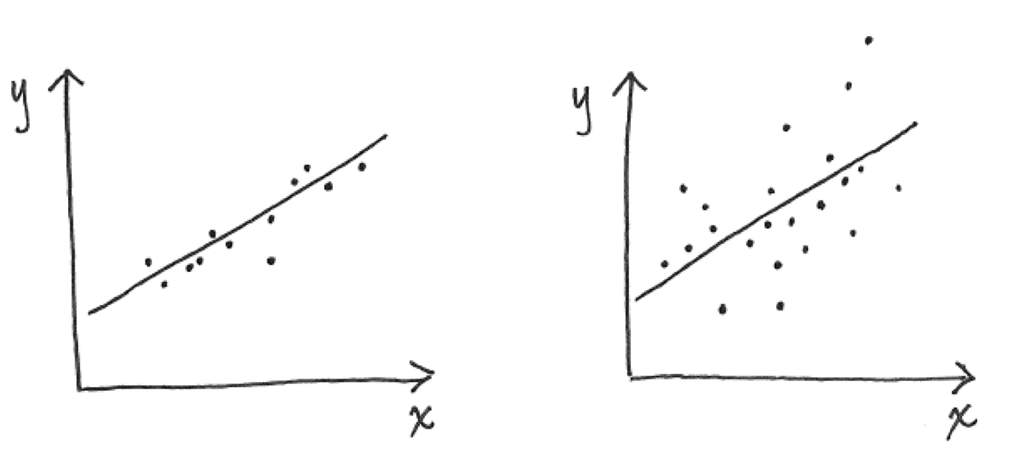

Variância do erro.

- Quanto maior $\sum_i\left(x_i -\bar{x}\right)^2$, menor $V\left[ \hat{\beta} | x \right]$

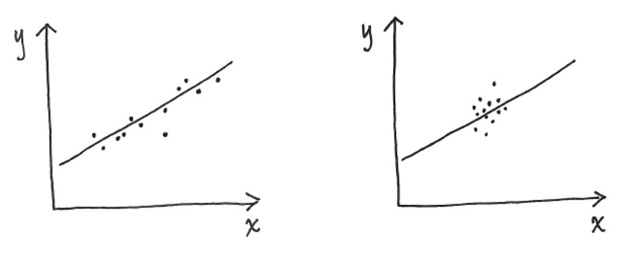

Variância de $x$.

- Quanto maior $N$, menor $V\left[ \hat{\beta} | x \right]$

## Propriedades dos Estimadores de MQO

**Teorema de Gauss-Markov**

Dadas as hipóteses **H1** até **H5**, os estimadores de mínimoas quadrados, $\hat{\beta}_0$ e $\hat{\beta}_1$, tem a menor variância entre todos os estimadores lineares não-viesados de $\beta_0$ e $\beta_1$.

#### Considerações

1. Os estimadores $\hat{\beta}_1$ e $\hat{\beta}_1$ são considerados “melhores” quando comparados a estimadores semelhantes, isto é, aqueles que são lineares e não viesados. O teorema não afirma que eles são os melhores entre todos os possíveis estimadores.
2. Os estimadores $\hat{\beta}_0$ e $\hat{\beta}_1$ são os melhores dentro de sua classe porque apresentam a variância mínima. Ao comparar dois estimadores lineares e não viesados, sempre preferimos utilizar aquele com menor variância.
3. Para que o Teorema de Gauss–Markov seja válido, as suposições **H1**–**H5** devem ser verdadeiras. Se qualquer uma dessas suposições não for satisfeita, então $\hat{\beta}_0$ e $\hat{\beta}_1$ não são os melhores estimadores lineares não-viesados de $\beta_1$ e $\beta_2$.
4. O Teorema de Gauss–Markov não depende da suposição de normalidade dos erros (**H6**).
5. O Teorema de Gauss–Markov se aplica aos estimadores de mínimos quadrados. Ele não se aplica às estimativas de mínimos quadrados obtidas a partir de uma única amostra.

## Propriedades dos Estimadores de MQO

**Consistência**

Argumento de Prova baseado na Lei dos Grandes Números

$$\hat{\beta}_{1}
= \frac{\sum_{i=1}^{n} (X_i - \bar{X})(Y_i - \bar{Y})}{\sum_{i=1}^{n} (X_i - \bar{X})^2}
= \beta_1
+ \frac{\sum_{i=1}^{n} (X_i - \bar{X})\,\varepsilon_i}{\sum_{i=1}^{n} (X_i - \bar{X})^2}
= \beta_1
+ \frac{\tfrac{1}{n}\sum_{i=1}^{n} (X_i - \bar{X})\,\varepsilon_i}{\tfrac{1}{n}\sum_{i=1}^{n} (X_i - \bar{X})^2}.$$

- O numerador no segundo termo **converge em probabilidade** para a covariância populacional $Cov(X,\varepsilon)$.
- O denominador no segundo termo **converge em probabilidade** para a variância populacional $V(X)$.

Se $Cov(X,\varepsilon) = 0$ e $V(X) \neq 0$, então:

$$\hat{\beta}_{1}
= \beta_1
+ \frac{\tfrac{1}{n}\sum_{i=1}^{n} (X_i - \bar{X})\,\varepsilon_i}{\tfrac{1}{n}\sum_{i=1}^{n} (X_i - \bar{X})^2}
\;\xrightarrow{p}\;
\beta_1 + \frac{\mathrm{Cov}(X,\varepsilon)}{\mathrm{Var}(X)} = \beta_1.$$

- O estimador de MQO é **consistente** — isto é, converge em probabilidade para o verdadeiro parâmetro $\beta_1$ — **quando** a covariância entre $X$ e o erro $\varepsilon$ é nula e a variância de $X$ é positiva.

## Distribuição dos Estimadores de MQO

**Distribuição de $\hat{\beta}_1$ e $\hat{\beta}_0$**

As propriedades dos estimadores de MQO que desenvolvemos até o momento não dependem de forma alguma da suposição de normalidade do $\varepsilon_i$.

Se também fizermos esta suposição, de que $\varepsilon_i \sim (0, \sigma^2)$, então as distribuições de probabilidade condicional dos estimadores de MQO também são normais.

#### Argumento

- Mas como precisamos estimar $V(\hat{\beta}_1$ e $V(\hat{\beta}_0)$, temos:

$$\begin{align*}
\frac{\hat{\beta}_1 - \beta_1}{\sqrt{V(\hat{\beta}_1)}} &\sim t_{n - 2} \\
\frac{\hat{\beta}_0 - \beta_0}{\sqrt{V(\hat{\beta}_0)}} &\sim t_{n - 2}
\end{align*}$$

## Distribuição dos Estimadores de MQO

**E se os erros não tiverem distribuição normal?**

- **Q:** Se os erros não seguirem uma distribuição normal, podemos dizer algo sobre a distribuição dos estimadores de MQO?
- **R:** Sim, às vezes.

#### Teorema Central do Limite

- Se H1–H5 forem válidas e $N$ “grande”, os estimadores de MQO tem distribuições aproximadamente normais como as anteriores, resultado **assintótico**:

$$\begin{align*}
\frac{\hat{\beta}_1 - \beta_1}{\sqrt{V(\hat{\beta}_1)}} &\sim N(0, 1) \\
\frac{\hat{\beta}_0 - \beta_0}{\sqrt{V(\hat{\beta}_0)}} &\sim N(0, 1)
\end{align*}$$

#### “Quão grande é suficiente?”

- **R:** Pergunta de 1 milhão.
- Não existe uma resposta única e válida para todas as situações.
- Depende de:
  - A distribuição dos erros é simétrica? assimétrica? Forte assimetria é o pior cenário..
  - Distribuição de $x_i$.
- Regras de bolso: $N \approx 30$ ou $N \approx 50$.
- Em resumo: depende do problema

## Estimador da Variância do Erro

**Estimador de $\sigma^2$**

- A variância do termo do erro aleatório, $\sigma^2$, é o único parâmetro desconhecido do modelo de regressão linear simples que precisa ser estimado.
- A variância condicional do erro aleatório $e_i$ é:

$$V(e_i \mid x) = \sigma^2 = E\{[e_i - E(e_i \mid x)]^2 \mid x\} = E(e_i^2 \mid x),$$

se a suposição $E(e_i \mid x) = 0$ for correta. Como a “expectativa” é um valor médio, podemos considerar estimar $\sigma^2$ como a média dos erros ao quadrado:

$$\sigma^2 = \frac{\sum e_i^2}{N}.$$

Infelizmente, esta fórmula não é útil, pois os erros aleatórios $e_i$ não são observáveis.

No entanto, embora os erros aleatórios sejam desconhecidos, temos um análogo a eles — os **resíduos dos mínimos quadrados**.

Recorde-se que os erros aleatórios são definidos como:

$$e_i = y_i - \beta_0 - \beta_1 x_i.$$

E que os resíduos dos mínimos quadrados são obtidos substituindo os parâmetros desconhecidos por suas estimativas de MQO:

$$\hat{e}_i = y_i - \hat{y}_i = y_i - \hat{\beta}_0 - \hat{\beta}_1 x_i.$$

De modo que:

$$\hat{\sigma}^2 = \frac{\sum \hat{e}_i^2}{N}.$$

Esse estimador, embora bastante satisfatório em amostras grandes, é **viesado** como estimador d e $\sigma^2$.

Mas há uma modificação simples que produz um estimador não viesado:

$$\boxed{\hat{\sigma}^2 = \frac{\sum_i^n(y_i - \hat{y}_i)^2}{N - 2} =\frac{\sum \hat{e}_i^2}{N - 2}}$$

O número $2$ subtraído no denominador corresponde ao número de parâmetros de regressão $(\beta_1, \beta_2)$ no modelo, e essa correção torna o estimador de $\sigma^2$ não viesado, de modo que $E(\hat{\sigma}^2 \mid x) = \sigma^2.$

## Medida da Qualidade do Ajuste

**Decomposição da Variância de $Y_i$**

- Vimos que podemos decompor $V(Y_i)$ como:

$$V(Y) =
\underbrace{E[V(Y|X)]}_{\text{variância dentro dos grupos}} +
\underbrace{V(E[Y|X])}_{\text{variância entre grupos}}$$

ou, de outra forma:

$$Y_i = E[Y_i \mid X_i] + \varepsilon_i
\tag{1}$$

- sendo $E[Y_i \mid X_i] = \beta_0 + \beta_1 X_i$, a variação sistemática em $Y_i$ explicada por $X_i$ e $\varepsilon_i$ a variação aleatória ou não explicada em $Y_i$.
- Embora ambas essas partes sejam não observáveis, podemos estimar os parâmetros desconhecidos $\beta_1$ e $\beta_2$ e, de forma análoga à Equação 1, decompor o valor de $y_i$ em:

$$\begin{align*}
y_i &= (\hat{\beta}_0 + \hat{\beta}_1 x_i) + (y_i - \hat{y}_i) \\
y_i &= \hat{y}_i + \hat{\varepsilon}_i \\
y_i - \bar{y}_i &= \hat{y}_i - \bar{y}_i + \hat{\varepsilon}_i \\
\sum_i^{n} (y_i - \bar{y}_i)^2 &= \sum_i^{n} (\hat{y}_i - \bar{y}_i)^2 + \sum_i (\hat{\varepsilon}_i)^2
\end{align*}$$

- $\sum_i^{n} (y_i - \bar{y}_i)^2$ = Soma de Quadrados Total (SQT) = medida da variação total de $y_i$ em relação à média.
- $\sum_i^{n} (\hat{y}_i - \bar{y}_i)^2$ = Soma de Quadrados do Modelo de Regressão (SQM) = parte da variação total de $y_i$ em torno de sua média explicada por $X_i$ ou pelo modelo de regressão, também conhecida como soma de quadrados explicada.
- $\sum_i^{n} (\hat{\varepsilon}_i)^2$ = Soma de Quadrados do Erro (SQR) = parte da variação total de $y$ em torno de sua média que não é explicada pelo modelo de regressão. Também conhecida como soma dos quadrados não explicada e soma dos quadrados resíduos.
- Assim, podemos escrever:

$$SQT = SQM + SQR$$

- Essa decomposição da variação total de $y$ em uma parte explicada pelo modelo de regressão e outra não explicada nos permite definir uma medida, denominada **coeficiente de determinação**, ou $R^2$, que representa a proporção da variação de $y$ explicada por $x$ ou pelo modelo de regressão:

$$\boxed{R^2 = \frac{SQM}{SQT} = 1 - \frac{SQR}{SQT}}$$

- Portanto $0 < R^2 < 1$ e é a proporção da variação total em $y$ explicada pelo modelo de regressão, sendo utilizada como uma medida da qualidade do ajuste.
- Entretanto, $R^2$ é uma medida limitada, pois simplesmente adicionar mais variáveis explicativas $x$ ao modelo, aumenta o $R^2$.

## Intervalos de Confiança

**Descrição**

- Sob as hipóteses **H1**-**H6**, podemos facilmente construir um intervalo de confianças para $\beta_0$ ou $\beta_1$.
- Usando o fato que:

$$\frac{\hat{\beta}_1 - \beta_1}{\widehat{ep}\!\big(\hat{\beta}_1\big)} \sim t_{n-2}$$

- manipulações simples implicam que um IC (95%) para qualque um dos parâmeros pode ser calculado com:

$$\hat{\beta} \pm c \times ep(\hat{\beta}) \\
[\hat{\beta} - c \times ep(\hat{\beta}), \hat{\beta} + c \times ep(\hat{\beta})]$$

- sendo $c$ o 97.5 quantil da distribuição $t$ com $n - 2$ graus de liberdade.
- podemos calcular facilnente o quantil $c$ em R:

```r
# número de observações
n <- 30
# graus de liberdade
gl <- n - 2
# valor crítico = quantil da distribuição t com n - 2 graus de liberdade
c <- qt(0.975, gl)
c
```

```
#> [1] 2.0484
```

## Testes de Hipóteses

**Descrição**

- Sob as hipóteses **H1**-**H6**, podemos facilmente construir um testes para os parâmetros populacionais $\beta_0$ ou $\beta_1$.
- Usando o fato que:

$$\frac{\hat{\beta}_1 - \beta_1}{\widehat{ep}\!\big(\hat{\beta}_1\big)} \sim t_{n-2}$$

- Exemplo: Teste t para verificar se cada estimativa é diferentes de zero:

$$\begin{align*}
H_0:\,\, & \beta_p = 0 \\
H_A:\,\, & \beta_p \neq 0 \\
t & = \frac{\hat{\beta} - 0}{EP(\hat{\beta})} \sim t_{(n-p,\alpha)}
\end{align*}$$

- **Se valor-p** $<$ **0.05** -> A estimativa **é** estatisticamente diferente de zero.
- **Se valor-p** $>$ **0.05** -> A estimativa **não é** estatisticamente diferente de zero.

## Testando Múltiplas Hipóteses

**Teste F**

- Usamos o teste$-t$ para testar hipóteses únicas, ou seja, hipóteses envolvendo apenas um parâmetro. Mas e se quisermos testar mais de um parâmetro **simultaneamente**?
- Fazemos isso usando o Teste$-F$. O Teste$-F$ envolve estimar 2 regressões:
  - Uma regressão **irrestrita**
  - Uma regressão **restrita**
- Considere o seguinte modelo de regressão múltipla:

$$Y_{i} = \beta_0 + \beta_1 X_{1} + \beta_2 X_{2} + \beta_3 X_{3} + \epsilon_{i}$$

- E que desejamos testar $H_0:\,\beta_2 + \beta_3 = 1$ ou $H_0:\, \beta_2 = 1$

## Testando Múltiplas Hipóteses

**Teste F**

- a regressão irrestrita é:

$$Y_{i} = \beta_0 + \beta_1 X_{1} + \beta_2 X_{2} + \beta_3 X_{3} + \epsilon_{i}$$
- a regressão restrita é:

$$\begin{align*}
Y_{i} &= \beta_0 + \beta_1 X_{1} + \beta_2 X_{2} + \beta_3 X_{3} + \epsilon_{i} \,\, sujeito\,\,a \quad (\beta_2 + \beta_3 = 1) \\
Y_{i} &= \beta_0 + \beta_1 X_{1} + \beta_2 X_{2} + (1-\beta_2) X_{3} + \epsilon_{i} \\
Y_{i} &= \beta_0 + \beta_1 X_{1} + \beta_2 X_{2} + X_{3} - \beta_2 X_{3} + \epsilon_{i} \\
Y_{i} - X_{3} &= \beta_0 + \beta_1 X_{1} + \beta_2 (X_{2} - X_{3}) + \epsilon_{i} \\
\end{align*}$$

## Testando Múltiplas Hipóteses

**Teste F**

- Estatística de Teste e Distribuição:

$$F_{calc} = \Biggl(\frac{SQR_{restrito} - SQR_{irrestrito}}{SQR_{irrestrito}}\Biggr) \frac{n - k}{m} \sim F_{(m,n-k)}$$

- sendo: $n=$ n. de observações, $k=$ número de preditores na regressão irrestrita e $m = $ número de restrições.
- Rejetia-se $H0$ contendo a restrição se $F_{calc} > F_{(m,n-k)}$, ou de analisando-se o valor-p:
- **Se valor-p** $<$ **0.05** -> Os resultados fornecem evidência para  
  rejeitar a $H0$ contendo a restrição.
- **Se valor-p** $>$ **0.05** -> OS resultados fornecem evidência para não rejeitar a $H0$ contendo a restrição.

## Testando Múltiplas Hipóteses: Teste$-F$

**Determinando o número de restrições em um teste$-F$:**

| $H_0$ : Hipóteses | N. de Restrições ($m$) |
| --- | --- |
| $H_0:\,\beta_2 + \beta_3 = 1$ | 1 |
| $H_0:$ $\beta_2 = 1$ e $\beta_3 = -1$ | 2 |
| $H_0:$ $\beta_1 = 0$, $\beta_2 = 0$ e $\beta_4 = 0$ | 3 |

## Linearidade

**Importante**

- O modelo de regressão linear simples é muito mais flexível do que parece à primeira vista.
- Ao transformar as variáveis $y$ e $x$, podemos representar muitas relações não lineares e ainda usar o modelo de regressão linear
- A questão é que o modelo não precisa necessariamente ser linear em relação às variáveis explicativas $x_i$.
- Para ser linear, um modelo de regressão **deve ser linear em relação aos parâmetros** ($\beta$).
- Linear nos parâmeros, significa que estes não são multiplicados ($\beta_0 \times \beta_1$), elevados a alguma potência ($\beta_0^{\beta_!}$), etc.

## Linearidade

**Exercício**

Os seguintes modelos de regressão são lineares?

1. $Y_i = e^{\beta_0 + \beta_1 X_i + \varepsilon_i}$
2. $\ln Y_i = \gamma_0 + \gamma_1 \dfrac{1}{X_i} + \varepsilon_i$
3. $\ln Y_i = \beta_0 + \beta_1^{\beta_0}X_i + \varepsilon_i$
4. $Y_I = \beta_0 + (\beta_0 - 1)\beta_1 X_i + \varepsilon_i$
5. $y_i = \beta_{0} + \beta _{1}x+ \beta _{2}x^{2} + \beta _{3}x^{3}+ \varepsilon _{i}$, (regressão polinomial).

## Interpretação das Estimativas dos Parâmetros

**Interpretação do Intercepto ($\hat{beta}_0$)**

- $\hat{\beta}_0$: Estimativa de $y$ quado as variáveis preditoras são iguais a zer, $X = 0$.
- $\hat{\beta}_0$: É preciso cuidado na interpretação (principalmente quando há poucas ou nenhuma observação próxima ao eixo $y$, veja fig.). Nem sempre a estimativa faz sentido ou e em diversos casos, não há interesse nesta estimativa.

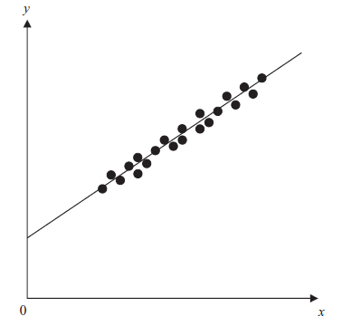

## Interpretação das Estimativas dos Parâmetros

Para $x_i$ sendo uma variável numérica, podemos interpretar $\hat{\beta}_1$ como:

$$\frac{\partial \hat{y_{i}}}{\partial x_{i}} = \hat{\beta}_1$$

Isto é, $\hat{\beta}$ mensura o efeito médio sobre $y_i$ do aumento de uma unidade em $x_i$.

## Interpretação das Estimativas dos Parâmetros

**Interpretação de $\hat{beta}_1$**

Para $x_i$ sendo uma variável numérica, podemos interpretar $\hat{\beta}_1$ como:

$$\frac{\partial \hat{y_{i}}}{\partial x_{i}} = \hat{\beta}_1$$

Isto é, $\hat{\beta}$ mensura o efeito médio sobre $y_i$ do aumento de uma unidade em $x_i$.

## Interpretação das Estimativas dos Parâmetros

**Variáveis Binárias**

Para $x_i$ sendo uma Variável binária ou *dummy*, temos:

$$x_i =
\begin{cases}
1 & \text{se i-ésima pessoa é mulher}, \\
0 & \text{se i-ésima pessoa é homem}
\end{cases}$$

Modelo resultante:

$$y_i = \beta_0 + \beta_1\ x_i + \epsilon_i =
\begin{cases}
\beta_0 + \beta_1 + \epsilon_i & \text{se i-ésima pessoa é mulher},\\
\beta_0 + \epsilon_i & \text{se i-ésima pessoa é homem}
\end{cases}$$

**Interpretação**: $\beta_1$ é a diferença média em $y_i$ entre o nível para o qual $x_i = 0$ (o nível de referência) e a categoria para a qual $x_i = 1$ (o nível de comparação).

## Transformação de Variáveis

**Logaritmos em modelos de regressão**

- Em diversos casos, podemos obter modelos melhores utilizando transformaçãoes das variáveis $Y$ e/ou $X$.
- Por quê?
- A primeira razão pode ser dar às variáveis propriedades estatísticas que funcionam melhor com a regressão. Por exemplo, podemos querer reduzir a assimetria (reduz a influência de outliers) e estabilizar a variância.

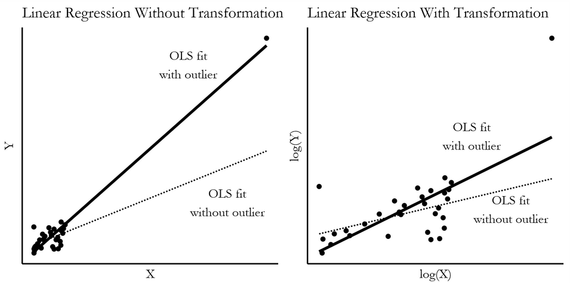

- A segunda razão para transformar uma variável é tentar obter uma relação linear entre as variáveis
- A teoria que fundamenta o modelo sugere a transformação. Por exemplo, os diversos tipos de elasticidades definidos na teoria microeconômica tem uma clara relação com logaritmos.
- Tomar Logaritmos, ou realizar a transformação logarítmica das variáveis, é uma das transformações mais utilizadas e comuns.

## Logaritmos em modelos de regressão

| Caso | Especificação | Interpretação de $\beta_1$ |
| --- | --- | --- |
| I | $Y_i = \beta_0 + \beta_1 \ln(X_1) + \epsilon_i$ | A variação de 1% em $X$ está associada a |
|  |  | uma variação média de 0,01$\beta_1$ em $Y_i$ |
| II | $\ln(Y_i) = \beta_0 + \beta_1 X_1 + \epsilon_i$ | A variação de 1 unidade em $X$ está associada a |
|  |  | uma variação média de 100$\beta_1$% em $Y_i$ |
| III | $\ln(Y_i) = \beta_0 + \beta_1 \ln(X_1) + \epsilon_i$ | A variação de 1% em $X$ está associada a |
|  |  | uma variação média de $\beta_1$% em $Y_i$ |

## Transformação de Variáveis

**Outras Transformações**

- As seguintes transformações são alternativas a problemas com logaritmos. Em particular, temos que $\log(0)$ é indefinido.
- $\log(x + 1)$: não recomendável.
- $\sqrt{x}$: transformação raíz quadrada. Reduz um pouco o peso dos outliers, mas não tão bem como logaritmos
- $\ln(x + \sqrt{x^2+1})$: função seno hiperbólica inversa. Reduz o peso dos outliers de forma similar aos logaritmos, sendo definida para zero. É a mais recomendada para dados com distribuição assimétrica e zeros.

```r
# função seno hiperbólica inversa em R
asinh(0)
```

```
#> [1] 0
```

## Transformação de Variáveis

*Winsorizing*

- Esta transformação não trata de assimetria ou linearização de um modelo, mas com *outliers* (valores extremos).
- *Winsorizing*, especialmente popular em finanças, é o processo de tomar alguns dados e remover os extremos.
- Para **Winsorizar** os top $X$ % dos dados superiores, tomamos todas as observações acima do percentil $p_i$ e as substituimos pelo percentil $p_i$.
- Por exemplo, se tivéssemos 100 observações de 1 a 100. Para Winsorizar os 5% dos ddados superiores e inferiores, mantemos as observações 6-95 e, em seguida, tomamos as observações 1, 2, 3, 4 e 5 e substituimoss por 6, e tomamos as observações 96, 97, 98, 99 e 100 oe substituimos por 95.
- Este é um método **força bruta** para lidar com outliers, mas tende a funcionar.

## Transformação de Variáveis

**Padronização**

- Mão melhora as propriedades estatísticas do modelo. Não lida com assimetria, *outliers* ou linearização.
- Esta é a transformação de padronizar uma variável subtraindo sua média e dividindo por seu desvio padrão $(x - \bar{x})/s_x$.
- Por que usar esta transformação? Porque pode tornar o modelo mais fácil de interpretar em alguns casos.
- se padronizarmos uma variável, a interpretação de $\hat{\beta}$ será então “*aumento de um desvio padrão em* $X$…”, o que pode ser mais fácil de avaliar em alguns casos.

# Aplicações

## Aplicação 1

**Jensen (1968)**

- Este estudo é um **seminal** na literatura de finanças por formalizar uma métrica quantitativa **(alfa de Jensen)** para avaliar o desempenho ajustado ao risco de gestores de portfólio — amplamente utilizada até hoje em avaliações de performance.
- Ver detalhes em Brooks (2019).

## Aplicação 2

**De Bondt e Thaler (1985) e De Bondt e Thaler (1987)**

#### De Bondt e Thaler (1985)

Este estudo pioneiro mostra que ações que sofreram grandes perdas (perdedoras) superam significativamente ações que obtiveram grandes ganhos (vencedoras) nos anos seguintes. A interpretação central é que investidores tendem a **superestimar eventos recentes**, levando os preços a se desviarem de seus valores fundamentais. A reversão subsequente dos preços é consistente com **viés comportamental de super-reação**, desafiando a hipótese de mercados eficientes.

#### De Bondt e Thaler (1987)

Este artigo confirma e estende os achados anteriores de reversão de preços entre vencedores e perdedores, revelando que grande parte do retorno dos perdedores ocorre em **janeiro**, especialmente em anos de baixa do mercado. O estudo descarta explicações baseadas apenas em tamanho de empresa ou risco (beta), e mostra que mudanças futuras nos lucros acompanham as reversões de preços, reforçando a hipótese de **super-reação dos investidores**.

- Ver detalhes em Brooks (2019).

## Aplicação 3

**Morck, Yeung e Yu (2000)**

- O artigo mostra que mercados emergentes exibem **alta sincronização nos preços das ações**, em contraste com mercados desenvolvidos. Isso é interpretado como sinal de **baixa eficiência informacional**, onde os preços refletem mais movimentos agregados do que informações específicas das empresas — muitas vezes devido a **instituições fracas, governança limitada e baixa transparência**.
- Os autores utilizam **regressão linear** para estimar o R² de mercado — ou seja, quanto da variação do retorno de uma ação individual pode ser explicada por um índice de mercado. Um R² elevado indica que os preços das ações se movem fortemente com o mercado, refletindo pouca incorporação de informação idiossincrática.

# Diagnóstico do Modelo de Regressão Linear Simples

## Diagnóstico do Modelo de Regressão Linear Simples

**Diagnóstico = Verificar as hipótes H1-H6**

- Uma vez estimado um ou mais modelos de regressão linear, é necessário verificar se as hipóteses nas quais o modelo se baseia para ser um bom modelo são suportadas pelos dados.
- Nesta seção veremos alguns diagnósticos gráficos dos resíduos do modelo.

## Diagnóstico Gráfico dos Resíduos

**Especificação Incorreta da Forma Funcional**

- Uma forma pela qual $H2$ (exogeneidade) pode falhar é se a relação funcional entre as variáveis explicada ($Y$) e explicativas ($X$) for especificada incorretamente na equação.
- O problema refere-se ao erro de modelar a relação entre as variáveis de maneira inadequada, como escolher uma relação linear quando a verdadeira relação é não linear.
- Esse tipo de erro pode resultar em estimativas viesadas.
- Por exemplo, se não incluirmos um termo quadrático $x^2$ quando ele deveria ser incluído.
- Outra especificação incorreta da forma funcional ocorre quando usamos o nível de uma variável, mas o logaritmo dessa variável é o que realmente aparece no modelo populacional, ou vice-versa.

## Diagnóstico do Modelo de Regressão Linear Simples

**Especificação Incorreta da Forma Funcional**

- O gráfico dos resíduos ($\hat{\varepsilon}_i$) versus os valores ajustados ($\hat{y}_i$) é uma ferramenta importante para verificar a hipótese de que os erros têm média zero condicionalmente às variáveis explicativas.
- Se os erros tiverem média zero, esperamos que os resíduos sejam distribuídos aleatoriamente em torno de zero, sem padrões discerníveis.
- Se houver padrões nos resíduos, isso pode indicar que a hipótese de que os erros têm média zero condicionalmente às variáveis explicativas não é válida.
- Este gráfico também pode ajudar a identificar problemas como heterocedasticidade e outliers.

## Gráfico dos Resíduos Adequado

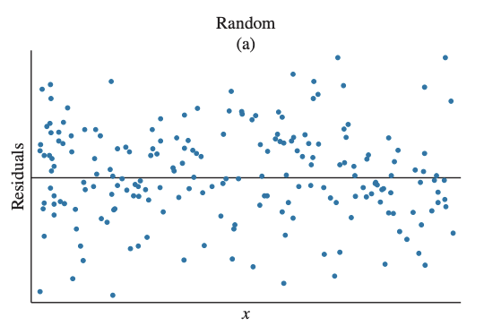

Resíduos não viesados, com variância condicional constante e não autocorrelacionados

## Especificação Incorreta da Forma Funcional

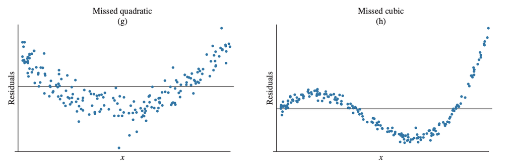

a) Não capturou um padrão quadrático b) Não capturou um padrão cúbico.

## Diagnóstico Gráfico dos Resíduos

**Detectando Heterocedasticidade**

Os gráficos a seguir mostram resíduos que não apresentam variância condicional constante, ou seja, apresentam **heterocedasticidade**.

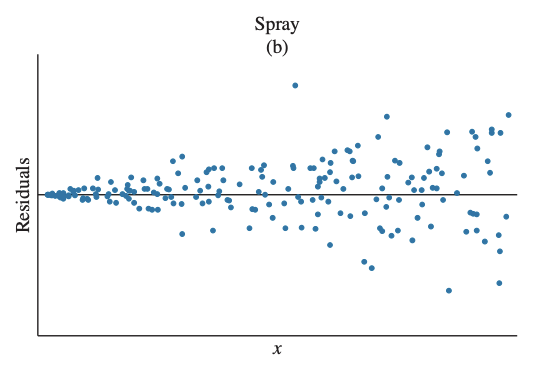

Variância do resíduo cresce com $x$.

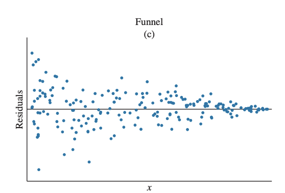

Variância do resíduo decresce com $x$.

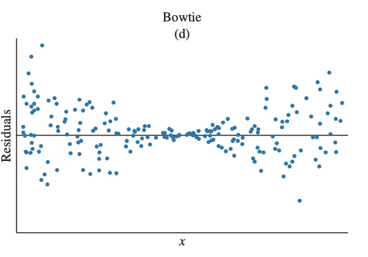

Variância nos extremos é diferente.

## Diagnóstico Gráfico dos Resíduos

**Detectando Correlação nos Resíduos**

Com dados de séries temporais, é muito comum observar resíduos correlacionados ou autocorrelacionados.

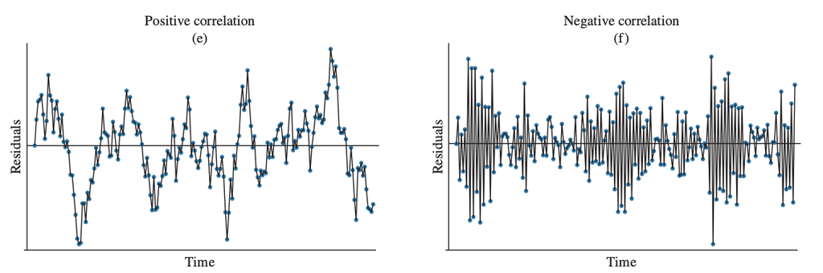

a) Resíduos com correlação positiva b) resíduos com correlação negativa.

## H6 - Normalidade dos Resíduos

**Normalidade dos Resíduos**

**Q.** Por que precisamos assumir normalidade dos resíduos no modelo de regressão linear clássico?

**R.** A **validade** dos procedimentos de **inferência estatística**:

- Estimativas de intervalos de confiança;
- Testes de hipóteses e;
- Previsões.

É baseada na hipótese de que os erros são normalmente distribuídos.

- Se os resíduos não são normalmente distribuídos, então os procedimentos de inferência podem ser **inválidos**

## Teste da Hipótese de Normalidade dos Resíduos

**Teste de Jarque-Bera**

- Uma distribuição normal é simétrica e tem um coeficiente de curtose de 3.
- A curtose de uma distribuição normal é 3, então o excesso de curtose ($b_{2} - 3$) é zero.
- O coeficiente de assimetria (skewness) e o de curtose são, respectivamente, o terceiro e o quarto momentos (padronizados) de uma distribuição.
- Jarque e Bera (1980) criaram um teste da normalidade dos resíduos, verificando se o coeficiente de assimetria e o coeficiente de curtose são conjuntamente iguais a 0 e 3, respectivamente.
- Pode-se provar que os coeficientes de assimetria e curtose podem ser expressos, respectivamente, como:

$$b_1 = \frac{E[u^3]}{\left( {\sigma ^2} \right)^{3 / 2}}{\quad}\hbox{e}{\quad}b_2 =
\frac{E[u^4]}{\left( {\sigma ^2} \right)^2}$$

- A estatística do teste de Jarque-Bera é dada por:

$$W = T\left[ {\frac{b_1 ^2}{6} + \frac{(b_2 - 3)^2}{24}} \right] \sim \chi_{(2)}^2$$

- Estimamos $b_{1}$ e $b_{2}$ utilizando os resíduos da regressão de MQO.
- **Hipótese Nula**: A amostra segue uma distribuição normal.

$$H_0: b_1 = 0 \quad \text{e} \quad b_2 = 3$$

- **Hipótese alternativa**: A amostra não segue uma distribuição normal.

$$H_1: b_1 \neq 0 \quad \text{ou} \quad b_2 \neq 3$$

- Este é um teste **assintótico**.
- Isto é, ele possui boas propriedades (poder) para amostras “grandes”.

## Teste de Jarque-Bera em R

```r
# carrega o pacote
library(DescTools)

# função para calcular o teste de Jarque-Bera
JarqueBeraTest(
  x, # vetor numérico com os resíduos
  robust = TRUE, # TRUE padrão, versão robusta do teste
  method = c("chisq", "mc"), # método para caluclar valores criticos
  N = 0, # número de simulações de Monte Carlo
  na.rm = FALSE # remover NA?
)
```

## Comparação de Testes de Normalidade

**Yap e Sim (2011)**

- Segundo os resultados do artigo de Yap e Sim (2011), o teste de Shapiro-Wilk obteve desempenho igual ou superior, em termos do poder do teste, aos demais testes comparados no estudo, sendo que o teste de Jarque-Bera estava incluído.
- O algoritmo utilizado para a implementação do teste de Shapiro-Wilk na linguagem R (utilizada neste artigo submetido) é o proposto por Royston (1995), o qual pode ser utilizado para qualquer n entre $3 \leq n \leq 5000$.

## Gráfico Quantil-Quantil Normal

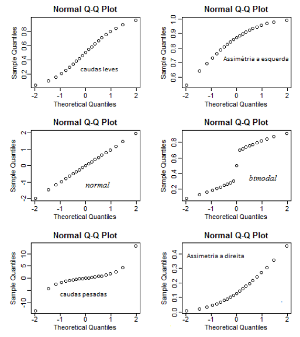

## Dados PublicSchools

**`PublicSchools`**

A data frame `PublicSchools`, disponível no pacote **sandwich** da linguagem R, contêm informações sobre escolas públicas nos EUA.

O conjunto de dados inclui 51 observações de 2 variáveis:

- **Expenditure** despesa per capita em escolas públicas, em dólares.
- **income** Renda per capita, em dólares.

## Gráficos Q-Q Normal - Pacote ggpubr

```r
# carrega os dados
data("PublicSchools", package = "sandwich")

# estima um modelo de regressão linear simples
ps_lm <- lm(Expenditure ~ Income, data = PublicSchools)

# extrai os resíduos do objeto ps_lm
ps_lm_residuos <- residuals(ps_lm)

# pacote utilizado
library(ggpubr)

# Gráfico quantil-quantil dos resíduos
ggqqplot(ps_lm_residuos) +
  xlab("Quantis teóricos de uma distribuição normal padrão") +
  ylab("Resíduos")
```

## Gráficos Q-Q Normal - Pacote ggpubr

[figure not shown]

# Regressão Linear Simples em R

## Função `lm()`

**Estrutura básica**

A função `lm()` estima modelos de regressão linear

```r
lm(formula, data, subset, weights, na.action)
```

- **formula:** especifica o modelo (ex.: `y ~ x1 + x2`)
- **data:** data frame contendo as variáveis
- **subset:** subconjunto de observações
- **weights:** pesos para MQO ponderado
- **na.action:** tratamento de valores ausentes

O resultado é um objeto da classe **`lm`**, contendo estimativas, resíduos e medidas de ajuste.

## Modelos com Logaritmos e Polinômios

**Transformações na especificação**

- **Logaritmos**

```r
lm(log(y) ~ log(x), data = df)
```

- **Termos polinomiais**

```r
lm(y ~ x + I(x^2), data = df)
```

## Principais Objetos do Modelo

**Componentes do objeto `lm`**

Um modelo ajustado, por exemplo:

```r
modelo <- lm(y ~ x1 + x2, data = df)
```

gera um objeto com diversos componentes que podem ser acessados com `names(modelo)`.

| Elemento | Acesso | Descrição |
| --- | --- | --- |
| Sumário | `summary(modelo)` | Estatísticas de teste e $R^2$ |
| Coeficientes | `modelo$coefficients` | Estimativas de $\boldsymbol{\beta}$ |
| Intervalos de confiança | `confint(modelo)` | Intervalos de confiança para os parâmetros |
| Resíduos | `modelo$residuals` | Diferenças $y_i - \hat{y}_i$ |
| Valores ajustados | `modelo$fitted.values` | Valores previstos $\hat{y}_i$ |
| Dados usados | `modelo$model` | Data frame interno |

Funções adicionais úteis: `vcov()` que fornece a matriz de variância-covariância.

## Testes de Hipóteses

**Função `car::linearHypothesis()`**

A função `linearHypothesis()` do pacote **car** permite realizar testes envolvendo combinações lineares dos parâmetros:

$$H_0: R\boldsymbol{\beta} = r$$

#### Exemplo

```r
modelo <- lm(y ~ x1 + x2, data = df)
car::linearHypothesis(modelo, c("x1 = 0", "x2 = 0"))
```

#### Resultado

A saída exibe a estatística **F**, o **valor-p** e a decisão sobre $H_0$. O teste é útil para **restrições simultâneas** ou **igualdade de coeficientes**.

## Função `tidy()` do pacote *broom*

**Resumo dos resultados do modelo**

A função `tidy()` organiza os resultados de modelos em formato *tidy*, retornando uma `tibble` com estimativas, erros-padrão, estatísticas t e valores-p.

```r
# estima um modelo de regressão linear simples
modelo <- lm(y ~ x1, data = df)

# exibe os resultados
broom::tidy(modelo, conf.int = TRUE, conf.level = 0.95)
```

#### Argumentos principais

| Argumento | Descrição |
| --- | --- |
| `conf.int` | Inclui colunas `conf.low` e `conf.high` com intervalos de confiança. |
| `conf.level` | Define o nível de confiança (padrão: 0.95). |
| `exponentiate` | Exponencia coeficientes e intervalos (útil em modelos log-lineares). |

A saída é compatível com o *tidyverse*, facilitando visualização e exportação de resultados.

#### Exemplo

```r
# exibe os resultados do modelo
broom::tidy(ps_lm, conf.int = TRUE, conf.level = 0.95)
```

```
#> # A tibble: 2 × 7
#>   term         estimate std.error statistic  p.value  conf.low conf.high
#>   <chr>           <dbl>     <dbl>     <dbl>    <dbl>     <dbl>     <dbl>
#> 1 (Intercept) -151.      64.1         -2.36 2.24e- 2 -280.      -22.3
#> 2 Income         0.0689   0.00835      8.26 9.05e-11    0.0522    0.0857
```

# Saída da Função `summary()`

## Resultado da Estimação de Modelo de Regressão em R

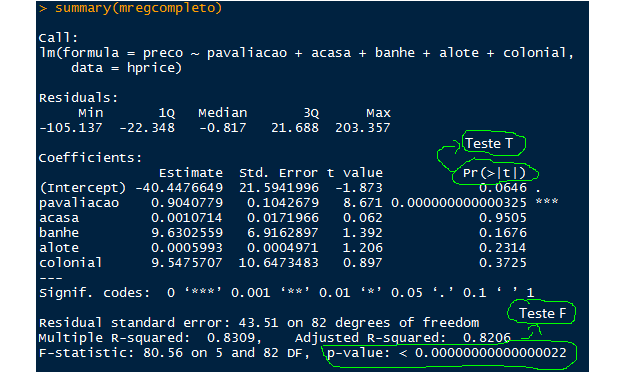

## Testes de Hipóteses/Significância

**Teste F**

**Teste F**: Testa se todas as estimativas dos parâmetros são iguais a zero.

$$\begin{align*}
H_0:\,\, & \beta_0 = \beta_1 = \ldots = \beta_k = 0 \\
H_A:\,\, & \text{Pelo menos um} \,\, \beta_k \neq 0 \\
F &= \Biggl(\frac{SQ_{total} - SQ_{residuo}}{SQ_{residuo}}\Biggr) \frac{n - k}{k - 1} \sim F_{(q,n-(k+1))}
\end{align*}$$

- **Se valor-p** $<$ **0.05** -> Pelo menos uma estimativa de um parâmetro é estatisticamente diferente de zero
- **Se valor-p** $>$ **0.05** -> Nenhuma estimativa de parâmetro é estatisticamente diferente de zero
- O teste $F$ é um instrumento para avaliar a significância global do modelo.

## Testes de Hipóteses/Significância

**Teste t**

- **Teste t**: Testa se cada estimativa é diferentes de zero:

$$\begin{align*}
H_0:\,\, & \beta_p = 0 \\
H_A:\,\, & \beta_p \neq 0 \\
t & = \frac{\hat{\beta} - 0}{EP(\hat{\beta})} \sim t_{(n-p,\alpha)}
\end{align*}$$

- Usando um software estatístico, é fácil calcular a probabilidade de observar um valor igual o maior que $|t|$, ou seja, o **valor-p**.
- **Se valor-p** $<$ **0.05** -> A estimativa **é** estatisticamente diferente de zero.
- **Se valor-p** $>$ **0.05** -> A estimativa **não é** estatisticamente diferente de zero.

## Medida da Qualidade do Ajuste

**$R^2$ = coeficiente de determinação**

- Medidas da *qualidade de ajuste* tentam analisar o quão bem nosso modelo descreve (*se ajusta*) aos dados.
- **Medida comum:** $R^2$ [R-quadrado] (*também conhecido como* coeficiente de determinação)

$$R^2 = \dfrac{\sum_i (\hat{y}_i - \overline{y})^2}{\sum_i \left( y_i - \overline{y} \right)^2} = 1 - \dfrac{\sum_i \left( y_i - \hat{y}_i \right)^2}{\sum_i \left( y_i - \overline{y} \right)^2}$$

- Observe nossa velha amiga RSS: $\sum_i \left( y_i - \hat{y}_i \right)^2 = \sum_i e_i^2 = \epsilon'\epsilon$.
- $R^2$ literalmente nos diz a parcela da variância em $y$ que nossos modelos atuais consideram. Assim, $0 \leq R^2 \leq 1$ (100%).
- **Problema:** À medida que adicionamos variáveis ao modelo, $R^2$ aumenta *mecanicamente*.

## Medida da Qualidade do Ajuste

**$R^2$-adj = coeficiente de determinação ajustado**

- Solução: O $R^2$-ajustado penaliza o número de variáveis no modelo.

$$\overline{R}^2 = 1 - \dfrac{\sum_i \left( y_i - \hat{y}_i \right)^2/(n-k-1)}{\sum_i \left( y_i - \overline{y} \right)^2/(n-1)}$$

- *Observação:* o $R^2$ ajustado não precisa estar entre 0 e 1.

## Referências

BROOKS, C. **Introductory Econometrics For Finance**. 4th. ed. [s.l.] Cambridge University Press, 2019.

DE BONDT, W. F. M.; THALER, R. [Does the Stock Market Overreact?](https://doi.org/10.2307/2327804) **The Journal of Finance**, v. 40, n. 3, p. 793–805, 1985.

___. [Further Evidence on Investor Overreaction and Stock Market Seasonality](https://doi.org/10.1111/j.1540-6261.1987.tb04569.x). **The Journal of Finance**, v. 42, n. 3, p. 557–581, 1987.

JARQUE, C. M.; BERA, A. K. Efficient tests for normality, homoscedasticity and serial independence of regression residuals. **Economics Letters**, v. 6, n. 3, p. 255–259, 1980.

JENSEN, M. C. [The Performance of Mutual Funds in the Period 1945–1964](https://doi.org/10.1111/j.1540-6261.1968.tb00815.x). **The Journal of Finance**, v. 23, n. 2, p. 389–416, mai. 1968.

MORCK, R.; YEUNG, B.; YU, W. The Information Content of Stock Markets: Why Do Emerging Markets Have Synchronous Stock Price Movements? **Journal of Financial Economics**, v. 58, n. 1–2, p. 215–260, 2000.

ROYSTON, P. Remark AS R94: A Remark on Algorithm AS 181: The W-test for Normality. **Journal of the Royal Statistical Society: Series C (Applied Statistics)**, v. 44, n. 4, p. 547–551, 1995.

YAP, B. W.; SIM, C. H. Comparisons of various types of normality tests. **Journal of Statistical Computation and Simulation**, v. 81, n. 12, p. 2141–2155, 2011.